# Session 4: SEM Practical

Ecological pathways, indirect effects and reporting

Oscar Rodriguez de Rivera | University of Exeter

```r
library(tidyverse)
library(lavaan)

theme_set(theme_minimal(base_size = 12))

# Optional packages used later:
# install.packages("semPlot")
# install.packages("piecewiseSEM")
# install.packages("DiagrammeR")
```

# 1 Session overview

## 1.1 Aim

This practical gives a small ecological SEM workflow using simulated data.

The goal is not to build a very large model. Instead, the aim is to practise the main SEM workflow:

1. state a pathway hypothesis;
2. inspect or simulate data;
3. fit component regression models;
4. calculate direct and indirect effects;
5. fit the same pathway as a single SEM;
6. compare alternative pathway structures;
7. report results carefully.

The practical builds directly on the SEM introduction document. The focus here is on applying the ideas to an ecological example.

## 1.2 Why SEM is useful in ecology

Ecological systems are often structured as networks of relationships.

For example, a plant response may depend on soil, climate and biotic interactions. Some effects may be direct, while others may operate through intermediate variables.

SEM is useful when the scientific question is not simply:

> Does (X) affect (Y)?

but instead:

> Through which pathways does (X) affect (Y)?

In this practical, the final response is **seed set**, but the pathway includes flower abundance and pollinator visits.

# 2 Ecological scenario

## 2.1 Biological motivation

Suppose we are interested in seed production in a plant community.

We hypothesise that:

- soil moisture and canopy openness affect flower abundance;
- flower abundance affects pollinator visits;
- pollinator visits affect seed set;
- temperature may affect flower abundance, pollinators and seed set directly.

This represents a simple ecological pathway.

For example, soil moisture may increase flower abundance. More flowers may attract more pollinators. More pollinator visits may then increase seed set.

So soil moisture may affect seed set indirectly, even if there is no direct arrow from soil moisture to seed set.

## 2.2 Hypothesised graphical model

Before fitting an SEM, it is important to state the hypothesised pathway structure.

In words, the model is:

```
##
## Soil moisture  ─┐
## Canopy openness ├──> Flower abundance ───> Pollinator visits ───> Seed set
## Temperature    ─┘              │                    │
##                                └────────────────────>│
## Temperature also affects pollinator visits and seed set directly.
```

More formally, the model includes these pathways:

- soil moisture → flower abundance;
- canopy openness → flower abundance;
- temperature → flower abundance;
- flower abundance → pollinator visits;
- temperature → pollinator visits;
- pollinator visits → seed set;
- flower abundance → seed set;
- temperature → seed set.

The SEM allows us to estimate all these pathways together.

# 3 Simulate data

## 3.1 Data-generating process

We simulate data from a known ecological pathway model.

This is useful for teaching because we know what the underlying structure is meant to be.

```r
set.seed(567)

n <- 220

eco_sem <- tibble(
  soil_moisture = rnorm(n),
  canopy_open = rnorm(n),
  temperature = rnorm(n)
) %>%
  mutate(
    flower_abundance =
      0.55 * soil_moisture +
      0.45 * canopy_open -
      0.20 * temperature +
      rnorm(n, sd = 0.7),
    pollinator_visits =
      0.75 * flower_abundance +
      0.25 * temperature +
      rnorm(n, sd = 0.8),
    seed_set =
      0.65 * pollinator_visits +
      0.25 * flower_abundance -
      0.15 * temperature +
      rnorm(n, sd = 0.8)
  )

dplyr::glimpse(eco_sem)
```

```
## Rows: 220
## Columns: 6
## $ soil_moisture     <dbl> 0.65674831, 0.33917190, -0.64075850, -1.44009620, 0.…
## $ canopy_open       <dbl> -2.25483414, -0.92256716, 0.66584894, -0.41552336, 0…
## $ temperature       <dbl> -0.1771425, 0.3078805, -0.4594924, 0.7208009, -0.577…
## $ flower_abundance  <dbl> -0.76003759, 0.10750700, 0.17503376, -2.43412420, 0.…
## $ pollinator_visits <dbl> 0.307491321, -0.015726612, 0.448305133, -2.477675562…
## $ seed_set          <dbl> -1.23884774, 1.46374050, -0.79682513, -1.85077884, 0…
```

## 3.2 Interpretation of the simulated model

The simulated model reflects the ecological story.

Flower abundance increases with soil moisture and canopy openness, and decreases slightly with temperature.

Pollinator visits increase when flower abundance is higher. Temperature also has a direct effect on pollinator visits.

Seed set increases with pollinator visits and flower abundance. Temperature has a small direct negative effect on seed set.

This gives a simple system with direct and indirect pathways.

# 4 Standardise variables

## 4.1 Why standardise?

Standardising variables puts them on a common scale.

After standardisation:

- each variable has mean 0;
- each variable has standard deviation 1.

This makes path coefficients easier to compare.

A standardised coefficient can be interpreted as the expected change in the response, in standard deviation units, for a one standard deviation increase in the predictor.

```r
eco_std <- eco_sem %>%
  dplyr::mutate(
    dplyr::across(
      .cols = everything(),
      .fns = ~ as.numeric(scale(.x))
    )
  )

dplyr::glimpse(eco_std)
```

```
## Rows: 220
## Columns: 6
## $ soil_moisture     <dbl> 0.7475741, 0.4417932, -0.5017405, -1.2713890, 0.3278…
## $ canopy_open       <dbl> -2.28213048, -0.94333451, 0.65286587, -0.43380586, 0…
## $ temperature       <dbl> -0.26538647, 0.25093216, -0.56595475, 0.69049577, -0…
## $ flower_abundance  <dbl> -0.65157162, 0.22792754, 0.29638480, -2.34872678, 0.…
## $ pollinator_visits <dbl> 0.45054655, 0.15299352, 0.58017914, -2.11346606, -0.…
## $ seed_set          <dbl> -0.83783015, 1.37161279, -0.47646406, -1.33810127, 0…
```

# 5 Explore the data

## 5.1 Response distributions

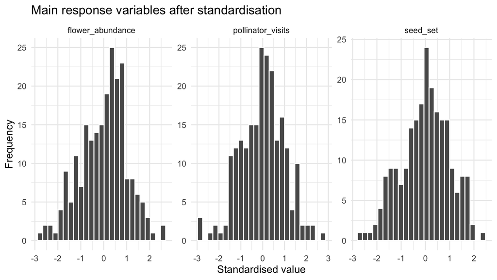

```r
eco_std %>%
  dplyr::select(flower_abundance, pollinator_visits, seed_set) %>%
  tidyr::pivot_longer(
    cols = everything(),
    names_to = "variable",
    values_to = "value"
  ) %>%
  ggplot(aes(x = value)) +
  geom_histogram(bins = 25, colour = "white") +
  facet_wrap(~ variable, scales = "free") +
  labs(
    title = "Main response variables after standardisation",
    x = "Standardised value",
    y = "Frequency"
  )
```

These plots help us check whether the main variables look approximately continuous and suitable for a simple linear SEM.

## 5.2 Correlation matrix

```r
round(cor(eco_std), 2)
```

```
##                   soil_moisture canopy_open temperature flower_abundance
## soil_moisture              1.00        0.03        0.00             0.62
## canopy_open                0.03        1.00        0.00             0.40
## temperature                0.00        0.00        1.00            -0.09
## flower_abundance           0.62        0.40       -0.09             1.00
## pollinator_visits          0.39        0.28        0.21             0.61
## seed_set                   0.35        0.25        0.02             0.60
##                   pollinator_visits seed_set
## soil_moisture                  0.39     0.35
## canopy_open                    0.28     0.25
## temperature                    0.21     0.02
## flower_abundance               0.61     0.60
## pollinator_visits              1.00     0.72
## seed_set                       0.72     1.00
```

The correlation matrix gives a first view of the relationships among variables.

However, correlations do not distinguish direct and indirect effects. SEM is useful because it allows us to represent a structured set of pathways.

## 5.3 Exploratory pathway plots

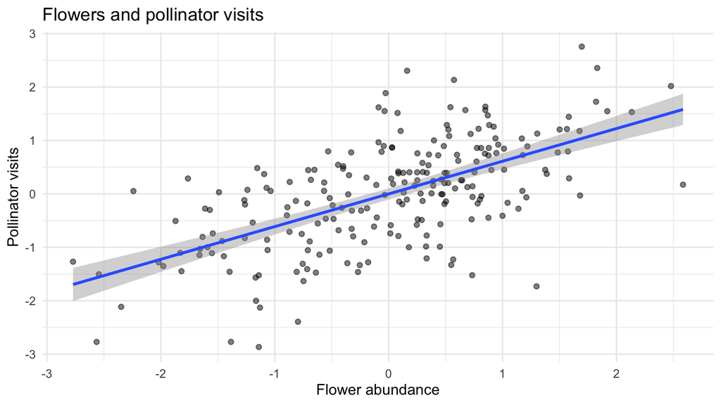

```r
p1 <- ggplot(eco_std, aes(x = flower_abundance, y = pollinator_visits)) +
  geom_point(alpha = 0.5) +
  geom_smooth(method = "lm", se = TRUE) +
  labs(
    title = "Flowers and pollinator visits",
    x = "Flower abundance",
    y = "Pollinator visits"
  )

p2 <- ggplot(eco_std, aes(x = pollinator_visits, y = seed_set)) +
  geom_point(alpha = 0.5) +
  geom_smooth(method = "lm", se = TRUE) +
  labs(
    title = "Pollinator visits and seed set",
    x = "Pollinator visits",
    y = "Seed set"
  )

p1
```

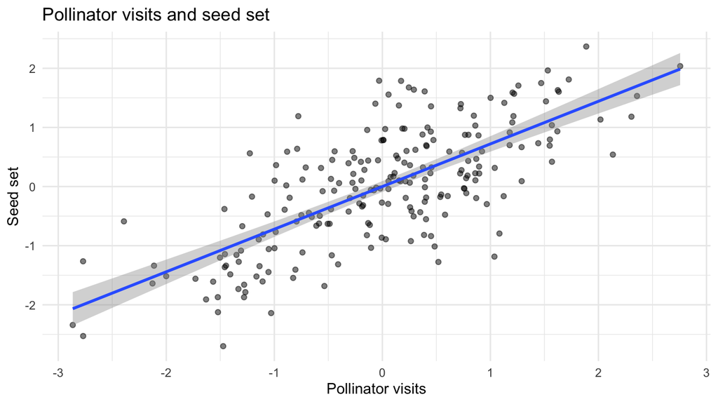

```r
p2
```

These plots show two important pathways, but each plot shows only one relationship at a time.

The SEM combines several relationships into one pathway model.

# 6 Piecewise-style component models

## 6.1 Fit each component model

Before fitting a full SEM, it is often useful to fit each component model separately.

Each endogenous variable gets its own regression.

An **endogenous variable** is a variable that appears as a response somewhere in the pathway model.

Here, the endogenous variables are:

- flower abundance;
- pollinator visits;
- seed set.

```r
flower_mod <- lm(
  flower_abundance ~ soil_moisture + canopy_open + temperature,
  data = eco_std
)

pollinator_mod <- lm(
  pollinator_visits ~ flower_abundance + temperature,
  data = eco_std
)

seed_mod <- lm(
  seed_set ~ pollinator_visits + flower_abundance + temperature,
  data = eco_std
)

summary(flower_mod)
```

```
##
## Call:
## lm(formula = flower_abundance ~ soil_moisture + canopy_open +
##     temperature, data = eco_std)
##
## Residuals:
##     Min      1Q  Median      3Q     Max
## -1.9166 -0.4268  0.0168  0.4194  1.5817
##
## Coefficients:
##                 Estimate Std. Error t value Pr(>|t|)
## (Intercept)    9.950e-19  4.578e-02   0.000   1.0000
## soil_moisture  6.118e-01  4.591e-02  13.327  < 2e-16 ***
## canopy_open    3.841e-01  4.591e-02   8.367 7.35e-15 ***
## temperature   -8.757e-02  4.588e-02  -1.908   0.0577 .
## ---
## Signif. codes:  0 '***' 0.001 '**' 0.01 '*' 0.05 '.' 0.1 ' ' 1
##
## Residual standard error: 0.679 on 216 degrees of freedom
## Multiple R-squared:  0.5452, Adjusted R-squared:  0.5389
## F-statistic: 86.33 on 3 and 216 DF,  p-value: < 2.2e-16
```

```r
summary(pollinator_mod)
```

```
##
## Call:
## lm(formula = pollinator_visits ~ flower_abundance + temperature,
##     data = eco_std)
##
## Residuals:
##      Min       1Q   Median       3Q      Max
## -2.30437 -0.41734 -0.00414  0.51420  2.27602
##
## Coefficients:
##                   Estimate Std. Error t value Pr(>|t|)
## (Intercept)      2.044e-17  5.043e-02   0.000        1
## flower_abundance 6.346e-01  5.074e-02  12.508   <2e-16 ***
## temperature      2.683e-01  5.074e-02   5.289    3e-07 ***
## ---
## Signif. codes:  0 '***' 0.001 '**' 0.01 '*' 0.05 '.' 0.1 ' ' 1
##
## Residual standard error: 0.748 on 217 degrees of freedom
## Multiple R-squared:  0.4455, Adjusted R-squared:  0.4404
## F-statistic: 87.19 on 2 and 217 DF,  p-value: < 2.2e-16
```

```r
summary(seed_mod)
```

```
##
## Call:
## lm(formula = seed_set ~ pollinator_visits + flower_abundance +
##     temperature, data = eco_std)
##
## Residuals:
##     Min      1Q  Median      3Q     Max
## -1.9036 -0.4521  0.0250  0.4693  1.4766
##
## Coefficients:
##                     Estimate Std. Error t value Pr(>|t|)
## (Intercept)        2.775e-17  4.468e-02   0.000 1.000000
## pollinator_visits  6.048e-01  6.014e-02  10.057  < 2e-16 ***
## flower_abundance   2.214e-01  5.896e-02   3.755 0.000223 ***
## temperature       -9.006e-02  4.775e-02  -1.886 0.060638 .
## ---
## Signif. codes:  0 '***' 0.001 '**' 0.01 '*' 0.05 '.' 0.1 ' ' 1
##
## Residual standard error: 0.6627 on 216 degrees of freedom
## Multiple R-squared:  0.5669, Adjusted R-squared:  0.5608
## F-statistic: 94.23 on 3 and 216 DF,  p-value: < 2.2e-16
```

## 6.2 Interpretation

The first model asks:

> Which environmental variables explain flower abundance?

The second model asks:

> Do flower abundance and temperature explain pollinator visits?

The third model asks:

> Do pollinator visits, flower abundance and temperature explain seed set?

This is why SEM can be viewed as a set of linked regressions.

# 7 Extract path coefficients

## 7.1 Component-model coefficients

```r
path_coefficients <- dplyr::bind_rows(
  broom::tidy(flower_mod) %>%
    dplyr::mutate(response = "flower_abundance"),
  broom::tidy(pollinator_mod) %>%
    dplyr::mutate(response = "pollinator_visits"),
  broom::tidy(seed_mod) %>%
    dplyr::mutate(response = "seed_set")
) %>%
  dplyr::filter(term != "(Intercept)") %>%
  dplyr::select(
    response,
    predictor = term,
    estimate,
    std.error,
    statistic,
    p.value
  )

path_coefficients
```

| response | predictor | estimate | std.error | statistic | p.value |
| --- | --- | --- | --- | --- | --- |
| flower_abundance | soil_moisture | 0.61184707 | 0.04591090 | 13.326837 | 5.742932e-30 |
| flower_abundance | canopy_open | 0.38413277 | 0.04591074 | 8.366949 | 7.351964e-15 |
| flower_abundance | temperature | -0.08756939 | 0.04588436 | -1.908480 | 5.765501e-02 |
| pollinator_visits | flower_abundance | 0.63461203 | 0.05073502 | 12.508362 | 2.172356e-27 |
| pollinator_visits | temperature | 0.26833498 | 0.05073502 | 5.288950 | 2.997318e-07 |
| seed_set | pollinator_visits | 0.60483125 | 0.06013803 | 10.057383 | 9.172286e-20 |
| seed_set | flower_abundance | 0.22140150 | 0.05896287 | 3.754931 | 2.229547e-04 |
| seed_set | temperature | -0.09006497 | 0.04775471 | -1.885991 | 6.063801e-02 |

Because the variables were standardised, these coefficients are directly comparable as standardised regression coefficients.

## 7.2 Reading the table

Each row is a pathway.

For example, the row with:

- response = `pollinator_visits`;
- predictor = `flower_abundance`;

represents the pathway:

```
## Flower abundance → Pollinator visits
```

The estimate gives the direction and strength of that path.

# 8 Direct, indirect and total effects

## 8.1 Direct effect

A direct effect is a single pathway from one variable to another.

For example:

```
## Flower abundance → Seed set
```

This is the direct effect of flower abundance on seed set.

## 8.2 Indirect effect

An indirect effect passes through at least one intermediate variable.

For example:

```
## Flower abundance → Pollinator visits → Seed set
```

This is an indirect effect of flower abundance on seed set via pollinator visits.

## 8.3 Total effect

The total effect is the sum of direct and indirect effects.

For example, the total effect of flower abundance on seed set is:

```
## Direct effect of flower abundance on seed set + indirect effect via pollinator visits
```

# 9 Calculate an indirect effect manually

## 9.1 Soil moisture to seed set

The effect of soil moisture on seed set is indirect because soil moisture is not included as a direct predictor of seed set.

One pathway is:

$$\text{soil moisture} \rightarrow \text{flower abundance} \rightarrow
\text{pollinator visits} \rightarrow \text{seed set}$$

Another pathway is:

$$\text{soil moisture} \rightarrow \text{flower abundance} \rightarrow
\text{seed set}$$

Therefore, the indirect effect is:

$$(a_1 \times b_1 \times c_1) + (a_1 \times c_2)$$

where:

- (a_1) is soil moisture → flower abundance;
- (b_1) is flower abundance → pollinator visits;
- (c_1) is pollinator visits → seed set;
- (c_2) is flower abundance → seed set.

```r
b_soil_flower <- coef(flower_mod)["soil_moisture"]
b_flower_pollinator <- coef(pollinator_mod)["flower_abundance"]
b_pollinator_seed <- coef(seed_mod)["pollinator_visits"]
b_flower_seed <- coef(seed_mod)["flower_abundance"]

indirect_soil_seed <-
  b_soil_flower * b_flower_pollinator * b_pollinator_seed +
  b_soil_flower * b_flower_seed

indirect_soil_seed
```

```
## soil_moisture
##     0.3703111
```

## 9.2 Interpretation

This number estimates the indirect effect of soil moisture on seed set through flower abundance and pollinator visits.

Because variables are standardised, the estimate is on a standardised scale.

A positive value means that higher soil moisture is associated with higher seed set through the pathway structure.

# 10 Fit the same model in lavaan

## 10.1 lavaan model syntax

The same pathway model can be written in `lavaan`.

In `lavaan`:

- `~` means “is regressed on”;
- `:=` defines a new parameter, such as an indirect effect.

```r
eco_model <- '
  flower_abundance ~ a1 * soil_moisture + a2 * canopy_open + a3 * temperature
  pollinator_visits ~ b1 * flower_abundance + b2 * temperature
  seed_set ~ c1 * pollinator_visits + c2 * flower_abundance + c3 * temperature

  indirect_soil_seed := a1 * b1 * c1 + a1 * c2
  indirect_canopy_seed := a2 * b1 * c1 + a2 * c2
  total_temperature_seed := c3 + b2 * c1 + a3 * c2 + a3 * b1 * c1
'
```

## 10.2 Fit the lavaan SEM

```r
eco_fit <- lavaan::sem(
  model = eco_model,
  data = eco_std,
  meanstructure = TRUE
)

summary(
  eco_fit,
  standardized = TRUE,
  fit.measures = TRUE,
  rsquare = TRUE
)
```

```
## lavaan 0.6-21 ended normally after 1 iteration
##
##   Estimator                                         ML
##   Optimization method                           NLMINB
##   Number of model parameters                        14
##
##   Number of observations                           220
##
## Model Test User Model:
##
##   Test statistic                                 1.459
##   Degrees of freedom                                 4
##   P-value (Chi-square)                           0.834
##
## Model Test Baseline Model:
##
##   Test statistic                               488.639
##   Degrees of freedom                                12
##   P-value                                        0.000
##
## User Model versus Baseline Model:
##
##   Comparative Fit Index (CFI)                    1.000
##   Tucker-Lewis Index (TLI)                       1.016
##
## Loglikelihood and Information Criteria:
##
##   Loglikelihood user model (H0)               -691.406
##   Loglikelihood unrestricted model (H1)       -690.677
##
##   Akaike (AIC)                                1410.812
##   Bayesian (BIC)                              1458.323
##   Sample-size adjusted Bayesian (SABIC)       1413.957
##
## Root Mean Square Error of Approximation:
##
##   RMSEA                                          0.000
##   90 Percent confidence interval - lower         0.000
##   90 Percent confidence interval - upper         0.059
##   P-value H_0: RMSEA <= 0.050                    0.929
```

[output cut: 34 more lines]

```
##    .flower_abundnc    0.453    0.043   10.488    0.000    0.453    0.455
##    .pollinatr_vsts    0.552    0.053   10.488    0.000    0.552    0.554
##    .seed_set          0.431    0.041   10.488    0.000    0.431    0.433
##
## R-Square:
##                    Estimate
##     flower_abundnc    0.545
##     pollinatr_vsts    0.446
##     seed_set          0.567
##
## Defined Parameters:
##                    Estimate  Std.Err  z-value  P(>|z|)   Std.lv  Std.all
##     indirect_sl_sd    0.370    0.043    8.614    0.000    0.370    0.370
##     indrct_cnpy_sd    0.232    0.034    6.746    0.000    0.232    0.232
##     totl_tmprtr_sd    0.019    0.060    0.318    0.750    0.019    0.019
```

## 10.3 What to look for

The output gives:

- estimated path coefficients;
- standardised path coefficients;
- indirect and total effects;
- model fit measures;
- (R^2) values for endogenous variables.

The (R^2) values show how much variation is explained in flower abundance, pollinator visits and seed set.

# 11 Graphical model

## 11.1 Path diagram

A path diagram is useful for communicating the SEM structure.

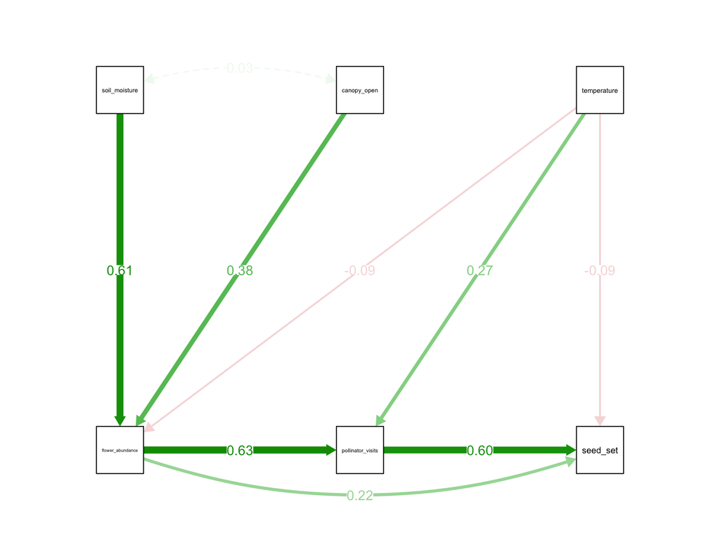

```r
if (requireNamespace("semPlot", quietly = TRUE)) {
  semPlot::semPaths(
    object = eco_fit,
    what = "std",
    whatLabels = "std",
    layout = "tree",
    style = "ram",
    residuals = FALSE,
    intercepts = FALSE,
    edge.label.cex = 0.9,
    sizeMan = 7,
    nCharNodes = 0
  )
} else {
  cat("Install the 'semPlot' package to display the graphical model.\n")
}
```

## 11.2 Interpretation

The arrows represent hypothesised pathways.

The numbers on the arrows are standardised coefficients.

A positive coefficient means that higher values of the predictor are associated with higher values of the response, after accounting for the other variables in that equation.

A negative coefficient means that higher values of the predictor are associated with lower values of the response.

# 12 Extract direct and indirect effects

## 12.1 lavaan effects table

```r
lavaan_effects <- lavaan::standardizedSolution(eco_fit) %>%
  tibble::as_tibble() %>%
  dplyr::filter(op %in% c("~", ":=")) %>%
  dplyr::select(lhs, op, rhs, est.std, se, z, pvalue)

lavaan_effects
```

| lhs | op | rhs | est.std | se | z | pvalue |
| --- | --- | --- | --- | --- | --- | --- |
| flower_abundance | ~ | soil_moisture | 0.61184707 | 0.03346207 | 18.2847956 | 0.000000e+00 |
| flower_abundance | ~ | canopy_open | 0.38413277 | 0.04117164 | 9.3300325 | 0.000000e+00 |
| flower_abundance | ~ | temperature | -0.08756939 | 0.04525086 | -1.9351985 | 5.296594e-02 |
| pollinator_visits | ~ | flower_abundance | 0.63461203 | 0.03886717 | 16.3277147 | 0.000000e+00 |
| pollinator_visits | ~ | temperature | 0.26833498 | 0.04825330 | 5.5609666 | 2.682846e-08 |
| seed_set | ~ | pollinator_visits | 0.60483125 | 0.05378840 | 11.2446400 | 0.000000e+00 |
| seed_set | ~ | flower_abundance | 0.22140150 | 0.05787182 | 3.8257220 | 1.303894e-04 |
| seed_set | ~ | temperature | -0.09006497 | 0.04716805 | -1.9094487 | 5.620423e-02 |
| indirect_soil_seed | := | a1*b1*c1+a1*c2 | 0.37031107 | 0.03387155 | 10.9328067 | 0.000000e+00 |
| indirect_canopy_seed | := | a2*b1*c1+a2*c2 | 0.23249048 | 0.03019071 | 7.7007295 | 1.354472e-14 |

[output cut: 1 more lines]

Rows with `op == "~"` are direct pathways.

Rows with `op == ":="` are defined effects, such as indirect or total effects.

# 13 Compare a simpler model

## 13.1 Remove the direct flower-to-seed pathway

We now compare the full model with a simpler model.

The simpler model removes the direct effect of flower abundance on seed set.

Biologically, this means we assume flowers affect seed set only through pollinator visits.

```r
eco_model_simple <- '
  flower_abundance ~ soil_moisture + canopy_open + temperature
  pollinator_visits ~ flower_abundance + temperature
  seed_set ~ pollinator_visits + temperature
'

fit_simple <- lavaan::sem(
  model = eco_model_simple,
  data = eco_std,
  meanstructure = TRUE
)

lavaan::lavTestLRT(
  fit_simple,
  eco_fit
)
```

|  | Df | AIC | BIC | Chisq | Chisq diff | RMSEA | Df diff | Pr(>Chisq) |
| --- | --- | --- | --- | --- | --- | --- | --- | --- |
| eco_fit | 4 | 1410.812 | 1458.323 | 1.459394 | NA | NA | NA | NA |
| fit_simple | 5 | 1422.724 | 1466.841 | 15.370751 | 13.91136 | 0.242256 | 1 | 0.0001916371 |

## 13.2 Interpretation

The likelihood ratio test compares the simpler and fuller models.

A small p-value suggests that removing the direct flower-to-seed pathway worsens model fit.

A large p-value suggests that the simpler model may be adequate.

In this simulated system, flower abundance has a direct effect on seed set, so the full model is expected to fit better.

## 13.3 Plot the simpler SEM

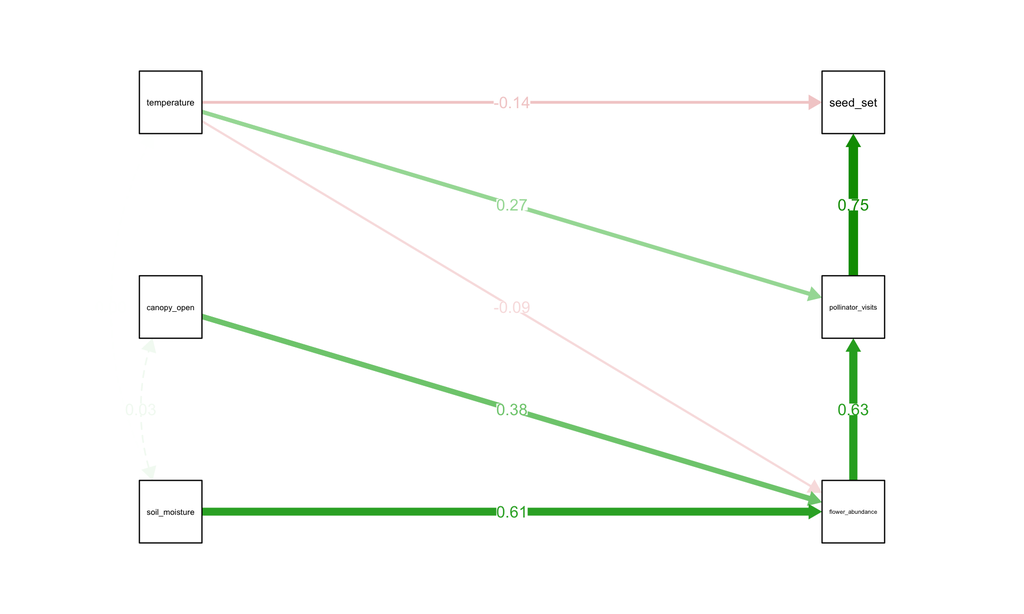

```r
semplot_available <- requireNamespace("semPlot", quietly = TRUE)

if (semplot_available) {
  semPlot::semPaths(
    fit_simple,
    what = "std",
    whatLabels = "std",
    layout = "tree",
    rotation = 2,
    residuals = FALSE,
    intercepts = FALSE,
    nCharNodes = 0,
    sizeMan = 7,
    edge.label.cex = 0.8,
    mar = c(5, 5, 5, 5)
  )
} else {
  message("Install semPlot to draw this model: install.packages('semPlot')")
}
```

Use the full and simpler diagrams side by side during teaching to ask:

> Which biological pathway has been removed, and does the model comparison support that simplification?

# 14 Reporting checklist

## 14.1 What to report

When reporting an SEM, include:

1. the biological or scientific rationale for the path structure;
2. which variables were treated as endogenous and exogenous;
3. whether variables were standardised;
4. fit indices or model comparison results;
5. direct, indirect and total effects;
6. a cautious statement about causal interpretation.

## 14.2 Example reporting paragraph

A possible reporting paragraph is:

> We fitted a structural equation model representing hypothesised pathways from soil moisture, canopy openness and temperature to flower abundance, pollinator visits and seed set. Variables were standardised before analysis, so path coefficients are comparable on a standardised scale. The model indicated that soil moisture and canopy openness were positively associated with flower abundance, flower abundance was positively associated with pollinator visits, and pollinator visits were positively associated with seed set. The effect of soil moisture on seed set was indirect, operating through flower abundance and pollinator visits. These results are consistent with the proposed pathway structure, but causal interpretation depends on the validity of the ecological assumptions and study design.

# 15 Exercise

## 15.1 Questions

1. Add a direct path from canopy openness to seed set. Is it supported?
2. Remove temperature from the pollinator model. What changes?
3. Calculate the indirect effect of canopy openness on seed set manually.
4. Write a two-sentence interpretation of the fitted model.

# 16 Exercise solution

## 16.1 1. Add a direct path from canopy openness to seed set

We add a new path from canopy openness directly to seed set.

## 16.3 2. Remove temperature from the pollinator model

Now we remove the direct pathway from temperature to pollinator visits.

## 16.5 3. Calculate the indirect effect of canopy openness on seed set manually

Canopy openness affects seed set indirectly through flower abundance.

There are two indirect pathways:

$$\text{canopy openness} \rightarrow \text{flower abundance} \rightarrow
\text{seed set}$$

and

$$\text{canopy openness} \rightarrow \text{flower abundance} \rightarrow
\text{pollinator visits} \rightarrow \text{seed set}$$

So the indirect effect is:

$$(a_2 \times c_2) + (a_2 \times b_1 \times c_1)$$

# 17 Optional extension: piecewise SEM

## 17.1 Why piecewise SEM?

The same logic can be extended to non-Gaussian and mixed models using the `piecewiseSEM` package.

Piecewise SEM is useful when SEM components include:

- GLMs;
- GLMMs;
- GAMs;
- random effects;
- non-normal responses;
- hierarchical sampling designs.

```r
if (requireNamespace("piecewiseSEM", quietly = TRUE)) {
  psem_fit <- piecewiseSEM::psem(
    flower_mod,
    pollinator_mod,
    seed_mod
  )

  summary(psem_fit)
} else {
  message("Install piecewiseSEM to run this section: install.packages('piecewiseSEM')")
}
```

[output not shown]

```
##
## Structural Equation Model of psem_fit
##
## Call:
##   flower_abundance ~ soil_moisture + canopy_open + temperature
##   pollinator_visits ~ flower_abundance + temperature
##   seed_set ~ pollinator_visits + flower_abundance + temperature
##
##     AIC
##  1410.812
##
## ---
## Tests of directed separation:
##
##                            Independ.Claim Test.Type  DF Crit.Value P.Value
##   pollinator_visits ~ soil_moisture + ...      coef 216    -0.1632  0.8705
##            seed_set ~ soil_moisture + ...      coef 215    -0.8268  0.4092
##     pollinator_visits ~ canopy_open + ...      coef 216     0.5829  0.5606
##              seed_set ~ canopy_open + ...      coef 215    -0.3480  0.7282
##
## --
## Global goodness-of-fit:
##
## Chi-Squared = 1.459 with P-value = 0.834 and on 4 degrees of freedom
## Fisher's C = 3.856 with P-value = 0.87 and on 8 degrees of freedom
##
## ---
## Coefficients:
##
##            Response         Predictor Estimate Std.Error  DF Crit.Value P.Value
##    flower_abundance     soil_moisture   0.6118    0.0459 216    13.3268  0.0000
##    flower_abundance       canopy_open   0.3841    0.0459 216     8.3669  0.0000
##    flower_abundance       temperature  -0.0876    0.0459 216    -1.9085  0.0577
##   pollinator_visits  flower_abundance   0.6346    0.0507 217    12.5084  0.0000
##   pollinator_visits       temperature   0.2683    0.0507 217     5.2889  0.0000
##            seed_set pollinator_visits   0.6048    0.0601 216    10.0574  0.0000
##            seed_set  flower_abundance   0.2214    0.0590 216     3.7549  0.0002
##            seed_set       temperature  -0.0901    0.0478 216    -1.8860  0.0606
##   Std.Estimate
##         0.6118 ***
##         0.3841 ***
##        -0.0876
##         0.6346 ***
##         0.2683 ***
##         0.6048 ***
##         0.2214 ***
##        -0.0901
##
##   Signif. codes:  0 '***' 0.001 '**' 0.01 '*' 0.05
##
## ---
## Individual R-squared:
##
##            Response method R.squared
##    flower_abundance   none      0.55
##   pollinator_visits   none      0.45
##            seed_set   none      0.57
```

## 17.2 Plot a piecewise SEM diagram

```r
diagrammer_available <- requireNamespace("DiagrammeR", quietly = TRUE)
piecewise_available <- requireNamespace("piecewiseSEM", quietly = TRUE)

if (diagrammer_available && piecewise_available) {

  psem_fit <- piecewiseSEM::psem(
    flower_mod,
    pollinator_mod,
    seed_mod
  )

  psem_coef <- piecewiseSEM::coefs(
    psem_fit,
    standardize = "scale"
  ) %>%
    as.data.frame(check.names = FALSE)

  names(psem_coef)[names(psem_coef) == ""] <- "significance"

  psem_coef <- tibble::as_tibble(psem_coef)

  make_label <- function(response, predictor) {
    this_path <- psem_coef %>%
      dplyr::filter(Response == response, Predictor == predictor)

    if (nrow(this_path) == 0) {
      return("")
    }

    est <- this_path$Std.Estimate[1]
    pval <- this_path$P.Value[1]

    stars <- dplyr::case_when(
      pval < 0.001 ~ "***",
      pval < 0.01  ~ "**",
      pval < 0.05  ~ "*",
      pval < 0.1   ~ ".",
      TRUE         ~ ""
    )

    paste0("b = ", round(est, 2), stars)
  }

  lab_soil_flower <- make_label("flower_abundance", "soil_moisture")
  lab_canopy_flower <- make_label("flower_abundance", "canopy_open")
  lab_temp_flower <- make_label("flower_abundance", "temperature")

  lab_flower_pollinator <- make_label("pollinator_visits", "flower_abundance")
  lab_temp_pollinator <- make_label("pollinator_visits", "temperature")

  lab_pollinator_seed <- make_label("seed_set", "pollinator_visits")
  lab_flower_seed <- make_label("seed_set", "flower_abundance")
  lab_temp_seed <- make_label("seed_set", "temperature")

  psem_graph <- paste0("
  digraph psem_model {

    graph [layout = dot, rankdir = LR]

    node [shape = box,
          style = filled,
          fillcolor = White,
          color = Black,
          fontname = Helvetica]

    edge [fontname = Helvetica,
          fontsize = 11,
          color = Black]

    soil_moisture [label = 'Soil moisture']
    canopy_open [label = 'Canopy openness']
    temperature [label = 'Temperature']

    flower_abundance [label = 'Flower abundance']
    pollinator_visits [label = 'Pollinator visits']
    seed_set [label = 'Seed set']

    soil_moisture -> flower_abundance [label = '", lab_soil_flower, "']
    canopy_open -> flower_abundance [label = '", lab_canopy_flower, "']
    temperature -> flower_abundance [label = '", lab_temp_flower, "']

    flower_abundance -> pollinator_visits [label = '", lab_flower_pollinator, "']
    temperature -> pollinator_visits [label = '", lab_temp_pollinator, "']

    pollinator_visits -> seed_set [label = '", lab_pollinator_seed, "']
    flower_abundance -> seed_set [label = '", lab_flower_seed, "']
    temperature -> seed_set [label = '", lab_temp_seed, "']
  }
  ")

  DiagrammeR::grViz(psem_graph)

} else {
  message("Install DiagrammeR and piecewiseSEM to draw this model.")
}
```

[interactive chart not shown]

# 18 Final reflection

This session has moved from:

- time series: recognising temporal structure;
- GAMs: modelling nonlinear smooth effects;
- SEM: linking variables through hypothesised pathways.

Together, these tools extend the earlier GLM and GLMM framework into richer applied modelling workflows.

The key message is:

> Choose the modelling framework based on the scientific question, the response type and the structure of the data.